# Gene X knockdown rescue assay: replicates, blocking and partial rescue

Adhithi Ravi Raghavan

October 2026

## Summary

This analysis looks at a **synthetic** cell-viability assay. A scientist tested whether knocking down **Gene X** rescues low viability in patient-derived disease cells, using two independent guides and a healthy reference.

The questions are:

1. **What is the real sample size?** There are 96 wells, but how many independent replicates?
2. **Does each knockdown raise viability compared with the disease control?**
3. **How much of the gap to healthy cells does each guide close?**

```r
library(tidyverse)
library(emmeans)
library(patchwork)
theme_set(theme_bw(base_size = 12))
```

## 1. Data and design

```r
d <- read_csv("data/rescue_assay.csv", show_col_types = FALSE) |>
  mutate(
    condition = factor(condition, levels = c("Healthy_NTC", "Disease_NTC",
                                             "Disease_GeneX_g1", "Disease_GeneX_g2")),
    donor = factor(donor),
    day = factor(day),
    block = interaction(donor, day, sep = "_")   # donor x plate/day
  )

table(d$plate, d$day)
```

```
##
##      Day1 Day2
##   P1   48    0
##   P2    0   48
```

```r
xtabs(~ condition + block, d)
```

```
##                   block
## condition          D1_Day1 D2_Day1 D3_Day1 D1_Day2 D2_Day2 D3_Day2
##   Healthy_NTC            4       4       4       4       4       4
##   Disease_NTC            4       4       4       4       4       4
##   Disease_GeneX_g1       4       4       4       4       4       4
##   Disease_GeneX_g2       4       4       4       4       4       4
```

The design is 3 donors × 4 conditions × 2 days × 4 wells, fully balanced, with no missing values. Three things matter:

- **Wells are technical replicates.** The independent unit is the **donor (n = 3)**, not the well (n = 96).
- **Plate is confounded with day.** Plate P1 was always Day 1 and P2 always Day 2, so a plate effect can’t be separated from a day effect. Every condition is on every plate, though, so each donor × plate is a complete block and condition comparisons within it are protected.
- **Well IDs are reused** (He1–4, Di1–4) across plates and conditions, so a well ID alone does not identify a well.

### Outliers and variance

```r
d <- d |>
  group_by(condition, donor, day) |>
  mutate(fold_vs_cell = viability_score / median(viability_score),
         flag = abs(log2(fold_vs_cell)) > 1) |>   # > 2-fold off its replicates
  ungroup()

filter(d, flag) |> select(donor, day, condition, well, viability_score, fold_vs_cell)
```

```
## # A tibble: 1 × 6
##   donor day   condition   well  viability_score fold_vs_cell
##   <fct> <fct> <fct>       <chr>           <dbl>        <dbl>
## 1 D1    Day2  Healthy_NTC He2               412         3.19
```

```r
cell <- d |> filter(!flag) |>
  group_by(condition, donor, day) |>
  summarise(mean = mean(viability_score), sd = sd(viability_score), .groups = "drop")
cor(cell$mean, cell$sd)
```

```
## [1] 0.6026586
```

One Healthy well (D1, Day 2) reads 412, about 3× its replicates. It looks like a data-entry or plate-reader error, so I exclude it and check the main result with it kept in (section 6). I screen on fold-difference from the replicate median rather than a MAD-based z-score, which overreacts in cells with very tight replicates.

Within-cell SD rises with the mean, so I model on the **log scale**: effects become fold-changes and the spread becomes roughly constant.

```r
d_clean <- filter(d, !flag)
```

## 2. Structure of the data

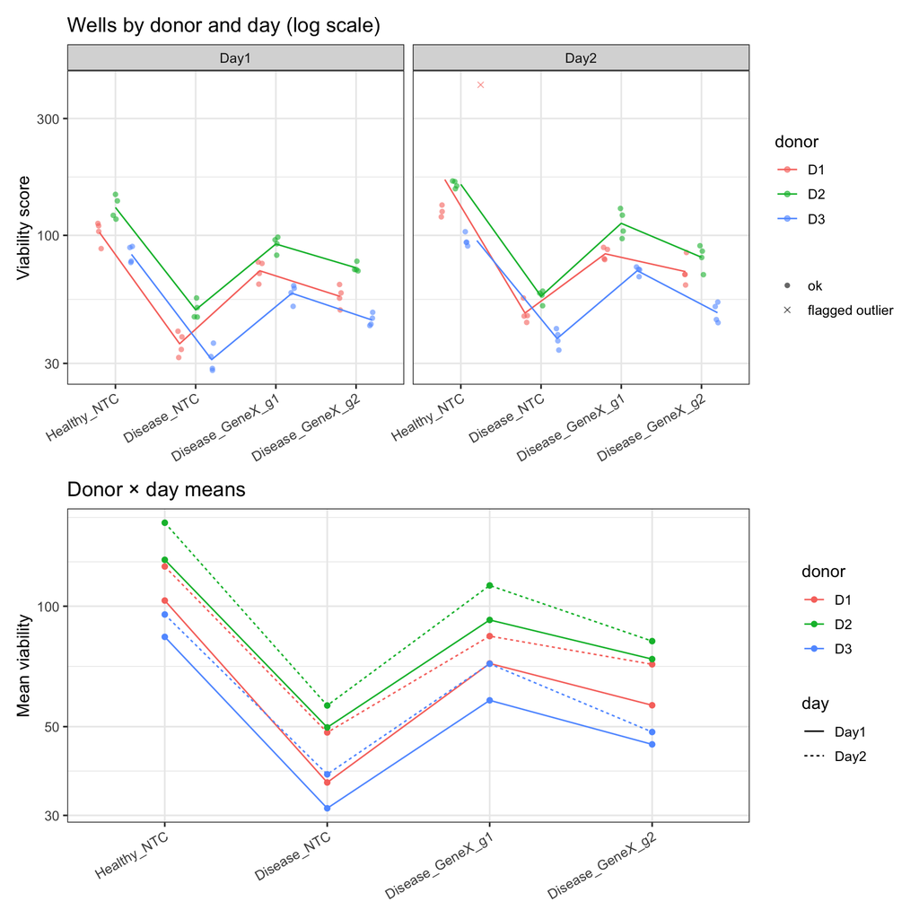

```r
p1 <- ggplot(d, aes(condition, viability_score, colour = donor)) +
  geom_point(aes(shape = flag),
             position = position_jitterdodge(jitter.width = 0.15, dodge.width = 0.6),
             alpha = 0.6) +
  stat_summary(aes(group = donor), fun = mean, geom = "line",
               position = position_dodge(0.6)) +
  facet_wrap(~ day) +
  scale_y_log10() +
  scale_shape_manual(values = c(16, 4), labels = c("ok", "flagged outlier"), name = NULL) +
  labs(title = "Wells by donor and day (log scale)", x = NULL, y = "Viability score") +
  theme(axis.text.x = element_text(angle = 30, hjust = 1))

p2 <- d_clean |>
  group_by(condition, donor, day) |>
  summarise(m = mean(viability_score), .groups = "drop") |>
  ggplot(aes(condition, m, group = interaction(donor, day), colour = donor, linetype = day)) +
  geom_line() + geom_point() +
  scale_y_log10() +
  labs(title = "Donor × day means", x = NULL, y = "Mean viability") +
  theme(axis.text.x = element_text(angle = 30, hjust = 1))

p1 / p2
```

All six donor × day profiles have the same shape: healthy is high, the disease control is low, guide 1 recovers more than guide 2. Day 2 reads higher across the board, and donors differ in baseline.

## 3. Model

I average the wells to one mean per donor × day × condition (24 values) and fit a log-scale linear model with a fixed effect for each donor × day block:

- Averaging stops the 4 technical wells being counted as independent samples.
- The block term removes each donor’s baseline and the day/plate shift.
- The condition effect is then tested against how consistently it repeats across donors and days, not against well-to-well noise.

```r
agg <- d_clean |>
  group_by(condition, donor, day, block) |>
  summarise(y = mean(viability_score), .groups = "drop")

m_agg <- lm(log(y) ~ condition + block, data = agg)
anova(m_agg)
```

```
## Analysis of Variance Table
##
## Response: log(y)
##           Df  Sum Sq Mean Sq F value    Pr(>F)
## condition  3 3.13917 1.04639  618.56 6.165e-16 ***
## block      5 1.07765 0.21553  127.41 9.755e-12 ***
## Residuals 15 0.02537 0.00169
## ---
## Signif. codes:  0 '***' 0.001 '**' 0.01 '*' 0.05 '.' 0.1 ' ' 1
```

A well-level mixed model, `lmer(log(y) ~ condition + day + (1|donor) + (1|donor:day) + (1|donor:condition))`, would give the same estimates; with balanced data and only three donors the averaged model is simpler and its degrees of freedom are honest.

## 4. Assumptions

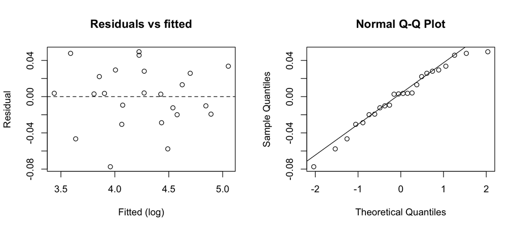

```r
par(mfrow = c(1, 2))
plot(fitted(m_agg), resid(m_agg), xlab = "Fitted (log)", ylab = "Residual",
     main = "Residuals vs fitted"); abline(h = 0, lty = 2)
qqnorm(resid(m_agg)); qqline(resid(m_agg))
```

```r
shapiro.test(resid(m_agg))
```

```
##
##  Shapiro-Wilk normality test
##
## data:  resid(m_agg)
## W = 0.96544, p-value = 0.5569
```

Residuals show no pattern against fitted values and sit close to the Q-Q line. With 24 values these checks have little power, so they rule out gross problems only.

## 5. Knockdowns vs disease control

```r
ctr <- contrast(emmeans(m_agg, ~ condition), method = "trt.vs.ctrl", ref = "Disease_NTC",
                type = "response", adjust = "dunnett")
confint(ctr)
```

```
##  contrast                       ratio     SE df lower.CL upper.CL
##  Healthy_NTC / Disease_NTC       2.69 0.0638 15     2.52     2.86
##  Disease_GeneX_g1 / Disease_NTC  1.89 0.0448 15     1.77     2.01
##  Disease_GeneX_g2 / Disease_NTC  1.45 0.0343 15     1.36     1.54
##
## Results are averaged over the levels of: block
## Confidence level used: 0.95
## Conf-level adjustment: dunnettx method for 3 estimates
## Intervals are back-transformed from the log scale
```

```r
ctr
```

```
##  contrast                       ratio     SE df null t.ratio p.value
##  Healthy_NTC / Disease_NTC       2.69 0.0638 15    1  41.595 <0.0001
##  Disease_GeneX_g1 / Disease_NTC  1.89 0.0448 15    1  26.721 <0.0001
##  Disease_GeneX_g2 / Disease_NTC  1.45 0.0343 15    1  15.526 <0.0001
##
## Results are averaged over the levels of: block
## P value adjustment: dunnettx method for 3 tests
## Tests are performed on the log scale
```

As a stricter check, I collapse the days too, leaving one value per donor × condition, so the effect is tested only against donor-to-donor variation (6 df):

```r
agg_donor <- agg |> group_by(condition, donor) |>
  summarise(y = exp(mean(log(y))), .groups = "drop")
m_donor <- lm(log(y) ~ condition + donor, data = agg_donor)
confint(contrast(emmeans(m_donor, ~ condition), "trt.vs.ctrl", ref = "Disease_NTC",
                 type = "response", adjust = "dunnett"))
```

```
##  contrast                       ratio     SE df lower.CL upper.CL
##  Healthy_NTC / Disease_NTC       2.69 0.0638  6     2.49     2.89
##  Disease_GeneX_g1 / Disease_NTC  1.89 0.0448  6     1.75     2.03
##  Disease_GeneX_g2 / Disease_NTC  1.45 0.0344  6     1.34     1.56
##
## Results are averaged over the levels of: donor
## Confidence level used: 0.95
## Conf-level adjustment: dunnettx method for 3 estimates
## Intervals are back-transformed from the log scale
```

Both knockdowns raise viability well above the disease control, and the conclusion is the same at either level.

## 6. How much of the gap is rescued?

The fraction rescued is (knockdown − disease control) / (healthy − disease control) on the log scale: 1 is full rescue, 0 is none. Because healthy is the reference level, this is `1 − b_kd / b_disease` in terms of model coefficients, and I get a confidence interval with the delta method.

```r
rescue_ci <- function(m, kd) {
  b <- coef(m); V <- vcov(m)
  nm <- c(paste0("condition", kd), "conditionDisease_NTC")
  est <- 1 - b[nm[1]] / b[nm[2]]
  grad <- c(-1 / b[nm[2]], b[nm[1]] / b[nm[2]]^2)
  se <- sqrt(drop(t(grad) %*% V[nm, nm] %*% grad))
  q <- qt(0.975, df.residual(m))
  tibble(guide = kd, fraction = est, lower = est - q * se, upper = est + q * se)
}
bind_rows(rescue_ci(m_agg, "Disease_GeneX_g1"),
          rescue_ci(m_agg, "Disease_GeneX_g2"))
```

```
## # A tibble: 2 × 4
##   guide            fraction lower upper
##   <chr>               <dbl> <dbl> <dbl>
## 1 Disease_GeneX_g1    0.642 0.597 0.687
## 2 Disease_GeneX_g2    0.373 0.328 0.418
```

With only three donors, the per-donor values are the most transparent summary:

```r
agg |>
  mutate(ly = log(y)) |>
  select(donor, day, condition, ly) |>
  pivot_wider(names_from = condition, values_from = ly) |>
  transmute(donor, day,
            g1 = (Disease_GeneX_g1 - Disease_NTC) / (Healthy_NTC - Disease_NTC),
            g2 = (Disease_GeneX_g2 - Disease_NTC) / (Healthy_NTC - Disease_NTC))
```

```
## # A tibble: 6 × 4
##   donor day      g1    g2
##   <fct> <fct> <dbl> <dbl>
## 1 D1    Day1  0.654 0.425
## 2 D1    Day2  0.581 0.411
## 3 D2    Day1  0.641 0.408
## 4 D2    Day2  0.657 0.352
## 5 D3    Day1  0.630 0.373
## 6 D3    Day2  0.692 0.265
```

I don’t use a donor bootstrap here: with three donors there are only 10 distinct resamples, so the interval would mostly reflect the most extreme donors and be too narrow.

### Sensitivity: outlier kept

```r
agg_all <- d |> group_by(condition, donor, day, block) |>
  summarise(y = mean(viability_score), .groups = "drop")
m_all <- lm(log(y) ~ condition + block, data = agg_all)
confint(contrast(emmeans(m_all, ~ condition), "trt.vs.ctrl", ref = "Disease_NTC",
                 type = "response", adjust = "dunnett"))
```

```
##  contrast                       ratio     SE df lower.CL upper.CL
##  Healthy_NTC / Disease_NTC       2.89 0.1630 15     2.50     3.36
##  Disease_GeneX_g1 / Disease_NTC  1.89 0.1060 15     1.63     2.19
##  Disease_GeneX_g2 / Disease_NTC  1.45 0.0816 15     1.25     1.68
##
## Results are averaged over the levels of: block
## Confidence level used: 0.95
## Conf-level adjustment: dunnettx method for 3 estimates
## Intervals are back-transformed from the log scale
```

Keeping the 412 well only moves the healthy estimate; the knockdown effects are unchanged.

## Conclusions

- **Finding:** Gene X knockdown substantially raised viability in disease cells from all three donors. Guide 1 closed about two-thirds of the gap to healthy cells and guide 2 about one-third.
- **Confidence:** the effect was very consistent across donors and days, but rests on three donors from one experiment, and the two guides disagree on its size.
- **Next step:** confirm knockdown efficiency for each guide (qPCR or western blot) to see whether the difference tracks knockdown level, add a third guide or a rescue construct to rule out off-target effects, and repeat in more donors.

### Limitations

- The data are synthetic, and the donors are unusually consistent, so the intervals are narrower than real data with n = 3 would give.
- Plate and day are confounded, and the plate layout is unknown, so position effects (such as edge wells) can’t be ruled out.
- The rescue fraction is defined on the log scale; on the raw scale the percentages differ somewhat.